# Análises modelos

2022-07-20

## Os dados

```r
dados5 <- readRDS("dados6.rds")

#criando variável chamada variante(original,gama,delta,omicron)
in_gama <- as.Date("01-02-2021",format="%d-%m-%Y")
in_delta <- as.Date("01-08-2021",format="%d-%m-%Y")
in_ommi <- as.Date("01-01-2022",format="%d-%m-%Y")

dados5 <- dados5 %>%
  mutate(variante = case_when(dt_sint < in_gama ~ "original",
                              dt_sint >= in_gama & dt_sint < in_delta ~ "gama",
                              dt_sint >= in_delta & dt_sint < in_ommi ~ "delta",
                              dt_sint >= in_ommi ~ "omicron")) %>%
  mutate(month_year = paste(formatC(month(dt_sint), width=2, format="d", flag="0"),
                            year(dt_sint),sep="/")) %>%
  mutate(mes = month(dt_sint))

dados5 <- dados5 %>%
    mutate(vacina_cov = ifelse(variante == "original","não",vacina_cov))



dados5$variante <- factor(dados5$variante,
                          levels = c("original", "gama", "delta","omicron"))

dados5 <- dados5 %>%
  filter(CLASSI_FIN == "5")

dados5 <- dados5 %>%
  mutate(dt_1dose = as.Date(DOSE_1_COV, format = "%d/%m/%Y")) %>%
  mutate(dt_2dose = as.Date(DOSE_2_COV, format = "%d/%m/%Y")) %>%
  mutate(doses = case_when(
    vacina_cov == "sim" & is.na(dt_1dose)
    & is.na(dt_2dose) ~ "pelo menos uma dose",
    !is.na(dt_2dose) ~ "duas doses",
    !is.na(dt_1dose) & is.na(dt_2dose) ~ "pelo menos uma dose",
    TRUE ~ "não informado"))


dados5 <- dados5 %>%
  mutate(vacinacov_variante2 = as.factor(case_when(
    variante == "original" ~ "original",
    variante == "gama" & vacina_cov == "sim" ~ "gama_vacinasim",
    variante == "gama" & vacina_cov == "não" ~ "gama_vacinanao",
    variante == "delta" & vacina_cov == "sim" ~ "delta_vacinasim",
    variante == "delta" & vacina_cov == "não" ~ "delta_vacinanao",
    variante == "omicron" & vacina_cov == "sim" ~ "omicron_vacinasim",
    variante == "omicron" & vacina_cov == "não" ~ "omicron_vacinanao",
    TRUE ~ NA_character_)))

dados5$vacinacov_variante2 <-
  factor(
    dados5$vacinacov_variante2,
    levels = c(
      "original",
      "gama_vacinanao",
      "gama_vacinasim",
      "delta_vacinanao",
      "delta_vacinasim",
      "omicron_vacinanao",
      "omicron_vacinasim"
    )
  )

dados5$vacina_cov <- as.factor(dados5$vacina_cov)
### 22.049
```

### Variável Evolução

#### Modelo Logistico

```r
modelo1 <- glm(data = dados5, as.factor(evolucao) ~ vacina_cov+variante, family = binomial)
summary(modelo1)
```

```
##
## Call:
## glm(formula = as.factor(evolucao) ~ vacina_cov + variante, family = binomial,
##     data = dados5)
##
## Deviance Residuals:
##     Min       1Q   Median       3Q      Max
## -0.5993  -0.4348  -0.3966  -0.2769   2.9510
##
## Coefficients:
##                 Estimate Std. Error z value Pr(>|z|)
## (Intercept)     -2.50303    0.04505 -55.558  < 2e-16 ***
## vacina_covsim   -0.93076    0.11898  -7.823 5.16e-15 ***
## variantegama     0.87702    0.06017  14.576  < 2e-16 ***
## variantedelta    0.19196    0.12983   1.479    0.139
## varianteomicron -0.90761    0.16403  -5.533 3.14e-08 ***
## ---
## Signif. codes:  0 '***' 0.001 '**' 0.01 '*' 0.05 '.' 0.1 ' ' 1
##
## (Dispersion parameter for binomial family taken to be 1)
##
##     Null deviance: 9653.6  on 15805  degrees of freedom
## Residual deviance: 9146.3  on 15801  degrees of freedom
##   (6243 observations deleted due to missingness)
## AIC: 9156.3
##
## Number of Fisher Scoring iterations: 6
```

```r
dados1 <- dados5[!is.na(dados5$evolucao) & !is.na(dados5$vacina_cov) & !is.na(dados5$variante),]
eta <- predict(modelo1)^2
fit.modelo1 <- glm(data = dados1, as.factor(evolucao) ~ vacina_cov+variante+eta, family = binomial)
anova(modelo1,fit.modelo1,test="LRT")
```

|  | Resid. Df | Resid. Dev | Df | Deviance | Pr(>Chi) |
| --- | --- | --- | --- | --- | --- |
| 1 | 15801 | 9146.272 | NA | NA | NA |
| 2 | 15800 | 9145.658 | 1 | 0.613705 | 0.4333962 |

```r
pregibon.glm(modelo1)
```

```
##
## The Pregibon Test p-value: 0. This model DOES NOT PASS this test.
```

```
##
##  Pregibon's Link Test
##
## data:  modelo1
## T.value = -5.7667, df = 15803, p-value = 8.233e-09
```

##### Análise de diagnóstico

Primeiramente, investigamos se não existe multicolinearidade nos dados, suposição muito importante em um modelo de regressão logística. Na prática, valores do teste Fator de Inflação da Variância (VIF) que excedam 10 indicam que há um problema de colinearidade. No entanto, como podemos observar em seguida, as covariáveis obtiveram valores de VIF bem abaixo de 5. Sendo assim, a condição de não-multicolinearidade está atestada.

```r
car::vif(modelo1)
```

```
##                GVIF Df GVIF^(1/(2*Df))
## vacina_cov 1.174086  1        1.083553
## variante   1.174086  3        1.027109
```

```r
hnp(modelo1)
```

```
## Binomial model
```

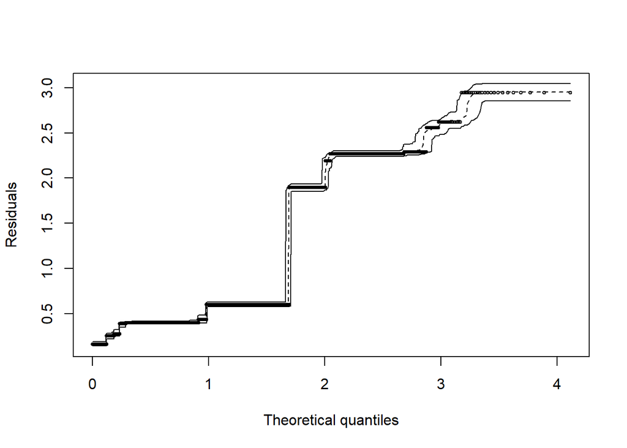

Figura 1: Gráfico de Envelope.

```r
# envelope(
#   modelo1, standardized = TRUE,
#   main = "", ylab = "quantis observados"
# )
```

#### Modelo Log-binomial

```r
modelo2 <- logbin(data = dados5, as.factor(evolucao) ~ vacina_cov+variante)
summary(modelo2)
```

```
##
## Call:
## logbin(formula = as.factor(evolucao) ~ vacina_cov + variante,
##     data = dados5)
##
## Deviance Residuals:
##     Min       1Q   Median       3Q      Max
## -0.5807  -0.5807  -0.3966  -0.3413   2.9713
##
## Coefficients:
##                 Estimate Std. Error z value Pr(>|z|)
## (Intercept)     -2.58169    0.04164 -61.994  < 2e-16 ***
## vacina_covsim   -1.00896    0.11189  -9.017  < 2e-16 ***
## variantegama     0.71839    0.05410  13.278  < 2e-16 ***
## variantedelta    0.71839    0.09509   7.555 4.20e-14 ***
## varianteomicron -0.82369    0.15795  -5.215 1.84e-07 ***
## ---
## Signif. codes:  0 '***' 0.001 '**' 0.01 '*' 0.05 '.' 0.1 ' ' 1
##
##     Null deviance: 9653.6  on 15805  degrees of freedom
## Residual deviance: 9179.2  on 15801  degrees of freedom
##   (6243 observations deleted due to missingness)
##
##   AIC: 9189.2
## AIC_c: 9189.2
##
## Number of iterations: 2410 (best: 1105)
```

```r
modelo3 <- glm(data = dados5, as.factor(evolucao) ~ vacina_cov+variante, family = binomial(link="log"))
summary(modelo3)
```

```
##
## Call:
## glm(formula = as.factor(evolucao) ~ vacina_cov + variante, family = binomial(link = "log"),
##     data = dados5)
##
## Deviance Residuals:
##     Min       1Q   Median       3Q      Max
## -0.5997  -0.4341  -0.3966  -0.2799   2.9398
##
## Coefficients:
##                 Estimate Std. Error z value Pr(>|z|)
## (Intercept)     -2.58169    0.04164 -61.994  < 2e-16 ***
## vacina_covsim   -0.85048    0.11191  -7.600 2.97e-14 ***
## variantegama     0.77741    0.05339  14.562  < 2e-16 ***
## variantedelta    0.17293    0.11949   1.447    0.148
## varianteomicron -0.88917    0.15927  -5.583 2.37e-08 ***
## ---
## Signif. codes:  0 '***' 0.001 '**' 0.01 '*' 0.05 '.' 0.1 ' ' 1
##
## (Dispersion parameter for binomial family taken to be 1)
##
##     Null deviance: 9653.6  on 15805  degrees of freedom
## Residual deviance: 9146.1  on 15801  degrees of freedom
##   (6243 observations deleted due to missingness)
## AIC: 9156.1
##
## Number of Fisher Scoring iterations: 7
```

```r
eta <- predict(modelo3)^2
fit.modelo3 <- glm(data = dados1, as.factor(evolucao) ~ vacina_cov+variante+eta, family = binomial(link="log"))
anova(modelo3,fit.modelo3,test="LRT")
```

|  | Resid. Df | Resid. Dev | Df | Deviance | Pr(>Chi) |
| --- | --- | --- | --- | --- | --- |
| 1 | 15801 | 9146.129 | NA | NA | NA |
| 2 | 15800 | 9145.860 | 1 | 0.2682225 | 0.6045266 |

```r
pregibon.glm(modelo2)
```

```
##
## The Pregibon Test p-value: 0. This model DOES NOT PASS this test.
```

```
##
##  Pregibon's Link Test
##
## data:  modelo2
## T.value = -5.1904, df = 15803, p-value = 2.124e-07
```

```r
pregibon.glm(modelo3)
```

```
##
## The Pregibon Test p-value: 0. This model DOES NOT PASS this test.
```

```
##
##  Pregibon's Link Test
##
## data:  modelo3
## T.value = -6.0324, df = 15803, p-value = 1.651e-09
```

##### Análise de diagnóstico

Primeiramente, investigamos se não existe multicolinearidade nos dados, suposição muito importante em um modelo de regressão logística. Na prática, valores do teste Fator de Inflação da Variância (VIF) que excedam 10 indicam que há um problema de colinearidade. No entanto, como podemos observar em seguida, as covariáveis obtiveram valores de VIF bem abaixo de 5. Sendo assim, a condição de não-multicolinearidade está atestada.

```r
car::vif(modelo2)
```

```
##                GVIF Df GVIF^(1/(2*Df))
## vacina_cov 1.158927  1        1.076535
## variante   1.158927  3        1.024887
```

```r
hnp(modelo2)
```

```
## Binomial model
```

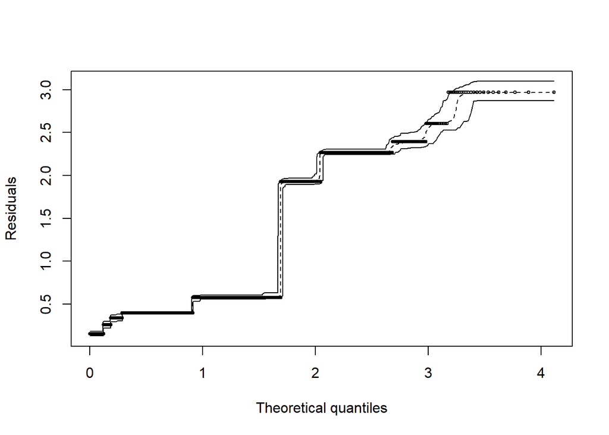

Figura 2: Gráfico de Envelope.

```r
# envelope(
#   modelo1, standardized = TRUE,
#   main = "", ylab = "quantis observados"
# )
```

```r
hnp(modelo3)
```

```
## Binomial model
```

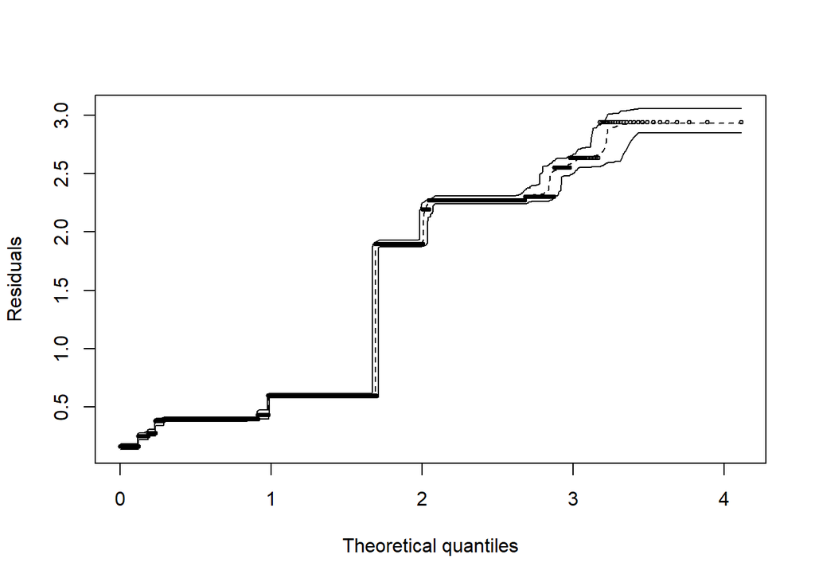

Figura 3: Gráfico de Envelope.

### Variável Uti

#### Modelo Logistico

```r
modelo1 <- glm(data = dados5, as.factor(uti) ~ vacina_cov+variante, family = binomial)
summary(modelo1)
```

```
##
## Call:
## glm(formula = as.factor(uti) ~ vacina_cov + variante, family = binomial,
##     data = dados5)
##
## Deviance Residuals:
##     Min       1Q   Median       3Q      Max
## -0.9388  -0.8354  -0.7349   1.4364   2.1651
##
## Coefficients:
##                 Estimate Std. Error z value Pr(>|z|)
## (Intercept)     -1.17109    0.02869 -40.825  < 2e-16 ***
## vacina_covsim   -0.27247    0.06424  -4.241 2.22e-05 ***
## variantegama     0.57023    0.04172  13.668  < 2e-16 ***
## variantedelta    0.58017    0.07299   7.949 1.89e-15 ***
## varianteomicron -0.79929    0.08413  -9.500  < 2e-16 ***
## ---
## Signif. codes:  0 '***' 0.001 '**' 0.01 '*' 0.05 '.' 0.1 ' ' 1
##
## (Dispersion parameter for binomial family taken to be 1)
##
##     Null deviance: 17674  on 15363  degrees of freedom
## Residual deviance: 17091  on 15359  degrees of freedom
##   (6685 observations deleted due to missingness)
## AIC: 17101
##
## Number of Fisher Scoring iterations: 4
```

```r
dados1 <- dados5[!is.na(dados5$uti) & !is.na(dados5$vacina_cov) & !is.na(dados5$variante),]
eta <- predict(modelo1)^2
fit.modelo1 <- glm(data = dados1, as.factor(uti) ~ vacina_cov+variante+eta, family = binomial)
anova(modelo1,fit.modelo1,test="LRT")
```

|  | Resid. Df | Resid. Dev | Df | Deviance | Pr(>Chi) |
| --- | --- | --- | --- | --- | --- |
| 1 | 15359 | 17090.99 | NA | NA | NA |
| 2 | 15358 | 17089.13 | 1 | 1.857841 | 0.1728741 |

```r
pregibon.glm(modelo1)
```

```
##
## The Pregibon Test p-value: 0.0018. This model DOES NOT PASS this test.
```

```
##
##  Pregibon's Link Test
##
## data:  modelo1
## T.value = -3.1265, df = 15361, p-value = 0.001772
```

##### Análise de diagnóstico

Primeiramente, investigamos se não existe multicolinearidade nos dados, suposição muito importante em um modelo de regressão logística. Na prática, valores do teste Fator de Inflação da Variância (VIF) que excedam 10 indicam que há um problema de colinearidade. No entanto, como podemos observar em seguida, as covariáveis obtiveram valores de VIF bem abaixo de 5. Sendo assim, a condição de não-multicolinearidade está atestada.

```r
car::vif(modelo1)
```

```
##                GVIF Df GVIF^(1/(2*Df))
## vacina_cov 1.403244  1        1.184586
## variante   1.403244  3        1.058089
```

```r
hnp(modelo1)
```

```
## Binomial model
```

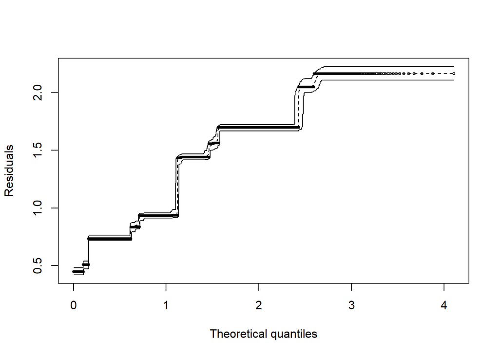

Figura 1: Gráfico de Envelope.

```r
# envelope(
#   modelo1, standardized = TRUE,
#   main = "", ylab = "quantis observados"
# )
```

#### Modelo Log-binomial

```r
modelo2 <- logbin(data = dados1, as.factor(uti) ~ vacina_cov+variante)
summary(modelo2)
```

```
##
## Call:
## logbin(formula = as.factor(uti) ~ vacina_cov + variante, data = dados1)
##
## Deviance Residuals:
##     Min       1Q   Median       3Q      Max
## -0.9437  -0.8290  -0.7349   1.4307   2.1570
##
## Coefficients:
##                 Estimate Std. Error z value Pr(>|z|)
## (Intercept)     -1.44114    0.02190 -65.814  < 2e-16 ***
## vacina_covsim   -0.19850    0.04650  -4.268 1.97e-05 ***
## variantegama     0.40455    0.02943  13.744  < 2e-16 ***
## variantedelta    0.41770    0.04969   8.406  < 2e-16 ***
## varianteomicron -0.68659    0.07121  -9.641  < 2e-16 ***
## ---
## Signif. codes:  0 '***' 0.001 '**' 0.01 '*' 0.05 '.' 0.1 ' ' 1
##
##     Null deviance: 17674  on 15363  degrees of freedom
## Residual deviance: 17090  on 15359  degrees of freedom
##
##   AIC: 17100
## AIC_c: 17100
##
## Number of iterations: 11390 (best: 6739)
```

```r
modelo3 <- glm(data = dados5, as.factor(uti) ~ vacina_cov+variante, family = binomial(link="log"))
summary(modelo3)
```

```
##
## Call:
## glm(formula = as.factor(uti) ~ vacina_cov + variante, family = binomial(link = "log"),
##     data = dados5)
##
## Deviance Residuals:
##     Min       1Q   Median       3Q      Max
## -0.9437  -0.8290  -0.7349   1.4307   2.1570
##
## Coefficients:
##                 Estimate Std. Error z value Pr(>|z|)
## (Intercept)     -1.44114    0.02190 -65.814  < 2e-16 ***
## vacina_covsim   -0.19850    0.04650  -4.268 1.97e-05 ***
## variantegama     0.40456    0.02943  13.744  < 2e-16 ***
## variantedelta    0.41769    0.04969   8.406  < 2e-16 ***
## varianteomicron -0.68659    0.07121  -9.641  < 2e-16 ***
## ---
## Signif. codes:  0 '***' 0.001 '**' 0.01 '*' 0.05 '.' 0.1 ' ' 1
##
## (Dispersion parameter for binomial family taken to be 1)
##
##     Null deviance: 17674  on 15363  degrees of freedom
## Residual deviance: 17090  on 15359  degrees of freedom
##   (6685 observations deleted due to missingness)
## AIC: 17100
##
## Number of Fisher Scoring iterations: 6
```

```r
eta <- predict(modelo3)^2
fit.modelo3 <- glm(data = dados1, as.factor(uti) ~ vacina_cov+variante+eta, family = binomial(link="log"))
anova(modelo3,fit.modelo3,test="LRT")
```

|  | Resid. Df | Resid. Dev | Df | Deviance | Pr(>Chi) |
| --- | --- | --- | --- | --- | --- |
| 1 | 15359 | 17089.97 | NA | NA | NA |
| 2 | 15358 | 17089.10 | 1 | 0.8725814 | 0.3502417 |

```r
pregibon.glm(modelo2)
```

```
##
## The Pregibon Test p-value: 0. This model DOES NOT PASS this test.
```

```
##
##  Pregibon's Link Test
##
## data:  modelo2
## T.value = -4.4135, df = 15361, p-value = 1.024e-05
```

```r
pregibon.glm(modelo3)
```

```
##
## The Pregibon Test p-value: 0. This model DOES NOT PASS this test.
```

```
##
##  Pregibon's Link Test
##
## data:  modelo3
## T.value = -4.4135, df = 15361, p-value = 1.024e-05
```

##### Análise de diagnóstico

Primeiramente, investigamos se não existe multicolinearidade nos dados, suposição muito importante em um modelo de regressão logística. Na prática, valores do teste Fator de Inflação da Variância (VIF) que excedam 10 indicam que há um problema de colinearidade. No entanto, como podemos observar em seguida, as covariáveis obtiveram valores de VIF bem abaixo de 5. Sendo assim, a condição de não-multicolinearidade está atestada.

```r
car::vif(modelo2)
```

```
##                GVIF Df GVIF^(1/(2*Df))
## vacina_cov 1.315586  1        1.146990
## variante   1.315586  3        1.046775
```

```r
hnp(modelo2)
```

```
## Binomial model
```

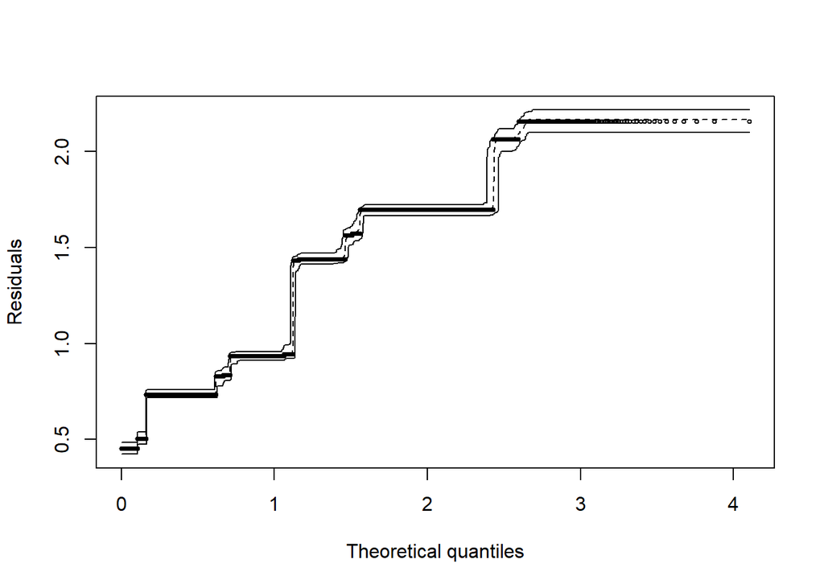

Figura 2: Gráfico de Envelope.

```r
# envelope(
#   modelo1, standardized = TRUE,
#   main = "", ylab = "quantis observados"
# )
```

```r
hnp(modelo3)
```

```
## Binomial model
```

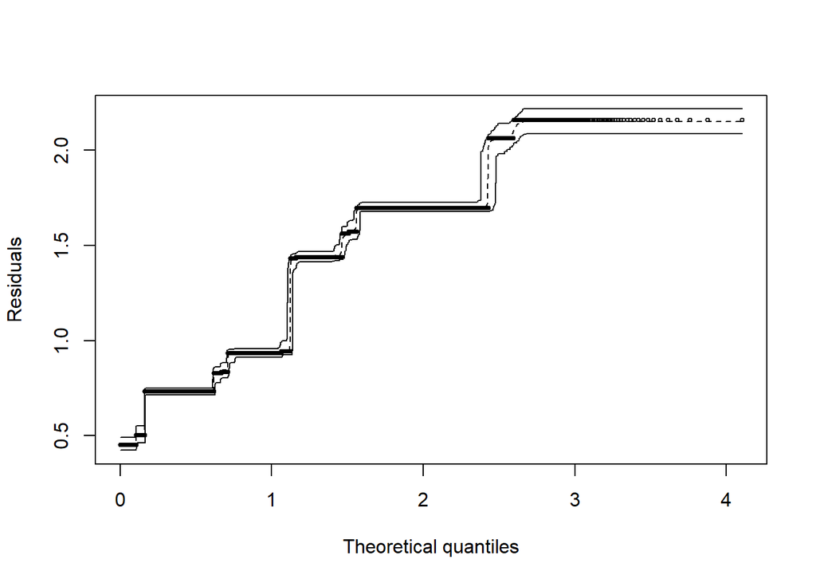

Figura 3: Gráfico de Envelope.

### Variável Suporte de ventilação

#### Modelo Logistico

```r
modelo1 <- glm(data = dados5, as.factor(suport_ven) ~ vacina_cov+variante, family = binomial)
summary(modelo1)
```

```
##
## Call:
## glm(formula = as.factor(suport_ven) ~ vacina_cov + variante,
##     family = binomial, data = dados5)
##
## Deviance Residuals:
##     Min       1Q   Median       3Q      Max
## -2.7196   0.2854   0.4652   0.5270   0.6606
##
## Coefficients:
##                 Estimate Std. Error z value Pr(>|z|)
## (Intercept)      2.16914    0.04054  53.506  < 2e-16 ***
## vacina_covsim    0.49257    0.09458   5.208 1.91e-07 ***
## variantegama    -0.75774    0.05496 -13.788  < 2e-16 ***
## variantedelta   -0.21459    0.10842  -1.979   0.0478 *
## varianteomicron  1.01122    0.14089   7.177 7.12e-13 ***
## ---
## Signif. codes:  0 '***' 0.001 '**' 0.01 '*' 0.05 '.' 0.1 ' ' 1
##
## (Dispersion parameter for binomial family taken to be 1)
##
##     Null deviance: 11167  on 15169  degrees of freedom
## Residual deviance: 10692  on 15165  degrees of freedom
##   (6879 observations deleted due to missingness)
## AIC: 10702
##
## Number of Fisher Scoring iterations: 6
```

```r
dados1 <- dados5[!is.na(dados5$suport_ven) & !is.na(dados5$vacina_cov) & !is.na(dados5$variante),]
eta <- predict(modelo1)^2
fit.modelo1 <- glm(data = dados1, as.factor(suport_ven) ~ vacina_cov+variante+eta, family = binomial)
anova(modelo1,fit.modelo1,test="LRT")
```

|  | Resid. Df | Resid. Dev | Df | Deviance | Pr(>Chi) |
| --- | --- | --- | --- | --- | --- |
| 1 | 15165 | 10692.05 | NA | NA | NA |
| 2 | 15164 | 10691.66 | 1 | 0.3955344 | 0.5294046 |

```r
pregibon.glm(modelo1)
```

```
##
## The Pregibon Test p-value: 0. This model DOES NOT PASS this test.
```

```
##
##  Pregibon's Link Test
##
## data:  modelo1
## T.value = 5.4315, df = 15167, p-value = 5.674e-08
```

##### Análise de diagnóstico

Primeiramente, investigamos se não existe multicolinearidade nos dados, suposição muito importante em um modelo de regressão logística. Na prática, valores do teste Fator de Inflação da Variância (VIF) que excedam 10 indicam que há um problema de colinearidade. No entanto, como podemos observar em seguida, as covariáveis obtiveram valores de VIF bem abaixo de 5. Sendo assim, a condição de não-multicolinearidade está atestada.

```r
car::vif(modelo1)
```

```
##                GVIF Df GVIF^(1/(2*Df))
## vacina_cov 1.255332  1        1.120416
## variante   1.255332  3        1.038627
```

```r
hnp(modelo1)
```

```
## Binomial model
```

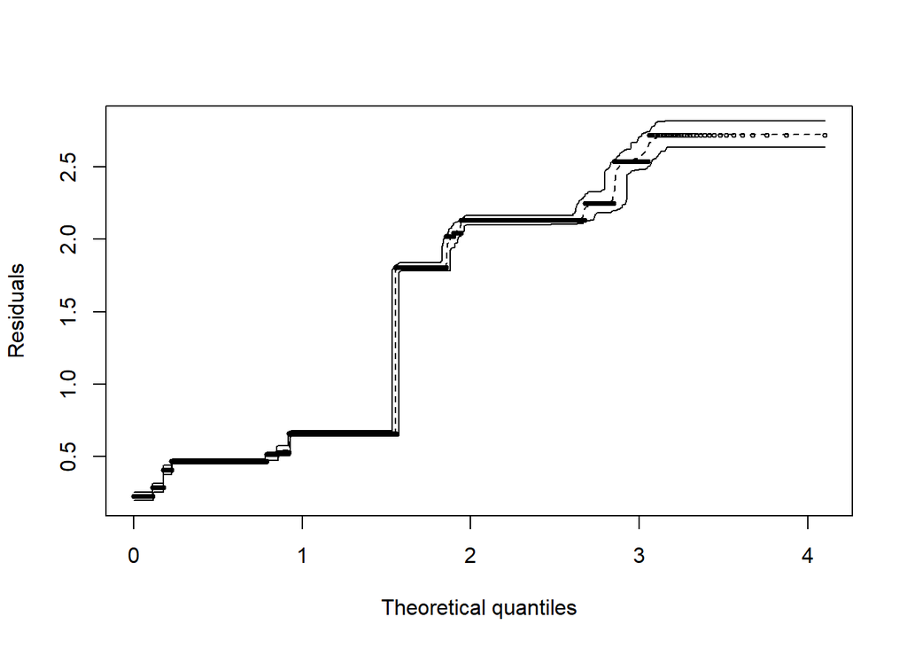

Figura 1: Gráfico de Envelope.

```r
# envelope(
#   modelo1, standardized = TRUE,
#   main = "", ylab = "quantis observados"
# )
```

#### Modelo Log-binomial

```r
modelo2 <- logbin(data = dados5, as.factor(suport_ven) ~ vacina_cov+variante)
summary(modelo2)
```

```
##
## Call:
## logbin(formula = as.factor(suport_ven) ~ vacina_cov + variante,
##     data = dados5)
##
## Deviance Residuals:
##     Min       1Q   Median       3Q      Max
## -2.7755   0.3341   0.4652   0.5949   0.6500
##
## Coefficients:
##                  Estimate Std. Error z value Pr(>|z|)
## (Intercept)     -0.108205   0.004158 -26.026  < 2e-16 ***
## vacina_covsim    0.034345   0.007677   4.473  7.7e-06 ***
## variantegama    -0.103070   0.007970 -12.931  < 2e-16 ***
## variantedelta   -0.014299   0.011080  -1.291    0.197
## varianteomicron  0.052389   0.008392   6.243  4.3e-10 ***
## ---
## Signif. codes:  0 '***' 0.001 '**' 0.01 '*' 0.05 '.' 0.1 ' ' 1
##
##     Null deviance: 11167  on 15169  degrees of freedom
## Residual deviance: 10701  on 15165  degrees of freedom
##   (6879 observations deleted due to missingness)
##
##   AIC: 10711
## AIC_c: 10711
##
## Number of iterations: 975 (best: 379)
```

```r
# modelo3 <- glm(data = dados5, as.factor(suport_ven) ~ vacina_cov+variante, family = binomial(link="log"))
# summary(modelo3)
```

```r
# eta <- predict(modelo3)^2
# fit.modelo3 <- glm(data = dados1, as.factor(suport_ven) ~ vacina_cov+variante+eta, family = binomial(link="log"))
# anova(modelo3,fit.modelo3,test="LRT")
```

```r
# pregibon.glm(modelo2)
```

```r
# pregibon.glm(modelo3)
```

##### Análise de diagnóstico

Primeiramente, investigamos se não existe multicolinearidade nos dados, suposição muito importante em um modelo de regressão logística. Na prática, valores do teste Fator de Inflação da Variância (VIF) que excedam 10 indicam que há um problema de colinearidade. No entanto, como podemos observar em seguida, as covariáveis obtiveram valores de VIF bem abaixo de 5. Sendo assim, a condição de não-multicolinearidade está atestada.

```r
car::vif(modelo2)
```

```
##                GVIF Df GVIF^(1/(2*Df))
## vacina_cov 2.479564  1        1.574663
## variante   2.479564  3        1.163400
```

```r
# hnp(modelo2)
# envelope(
#   modelo1, standardized = TRUE,
#   main = "", ylab = "quantis observados"
# )
```

```r
# hnp(modelo3)
```

### Variável Febre

#### Modelo Logistico

```r
modelo1 <- glm(data = dados5, as.factor(febre) ~ vacina_cov+variante, family = binomial)
summary(modelo1)
```

```
##
## Call:
## glm(formula = as.factor(febre) ~ vacina_cov + variante, family = binomial,
##     data = dados5)
##
## Deviance Residuals:
##     Min       1Q   Median       3Q      Max
## -1.4109  -1.3714   0.9606   0.9951   1.3034
##
## Coefficients:
##                 Estimate Std. Error z value Pr(>|z|)
## (Intercept)      0.53393    0.02541  21.009  < 2e-16 ***
## vacina_covsim   -0.10932    0.05600  -1.952  0.05093 .
## variantegama    -0.08874    0.03942  -2.251  0.02438 *
## variantedelta   -0.20067    0.06922  -2.899  0.00374 **
## varianteomicron -0.71591    0.06426 -11.141  < 2e-16 ***
## ---
## Signif. codes:  0 '***' 0.001 '**' 0.01 '*' 0.05 '.' 0.1 ' ' 1
##
## (Dispersion parameter for binomial family taken to be 1)
##
##     Null deviance: 19863  on 14689  degrees of freedom
## Residual deviance: 19627  on 14685  degrees of freedom
##   (7359 observations deleted due to missingness)
## AIC: 19637
##
## Number of Fisher Scoring iterations: 4
```

```r
dados1 <- dados5[!is.na(dados5$febre) & !is.na(dados5$vacina_cov) & !is.na(dados5$variante),]
eta <- predict(modelo1)^2
fit.modelo1 <- glm(data = dados1, as.factor(febre) ~ vacina_cov+variante+eta, family = binomial)
anova(modelo1,fit.modelo1,test="LRT")
```

|  | Resid. Df | Resid. Dev | Df | Deviance | Pr(>Chi) |
| --- | --- | --- | --- | --- | --- |
| 1 | 14685 | 19626.76 | NA | NA | NA |
| 2 | 14684 | 19613.77 | 1 | 12.98203 | 0.000314495 |

```r
pregibon.glm(modelo1)
```

```
##
## The Pregibon Test p-value: 0.1962. This model DOES PASS this test.
```

```
##
##  Pregibon's Link Test
##
## data:  modelo1
## T.value = -1.2925, df = 14687, p-value = 0.1962
```

##### Análise de diagnóstico

Primeiramente, investigamos se não existe multicolinearidade nos dados, suposição muito importante em um modelo de regressão logística. Na prática, valores do teste Fator de Inflação da Variância (VIF) que excedam 10 indicam que há um problema de colinearidade. No entanto, como podemos observar em seguida, as covariáveis obtiveram valores de VIF bem abaixo de 5. Sendo assim, a condição de não-multicolinearidade está atestada.

```r
car::vif(modelo1)
```

```
##                GVIF Df GVIF^(1/(2*Df))
## vacina_cov 1.588919  1        1.260523
## variante   1.588919  3        1.080232
```

```r
hnp(modelo1)
```

```
## Binomial model
```

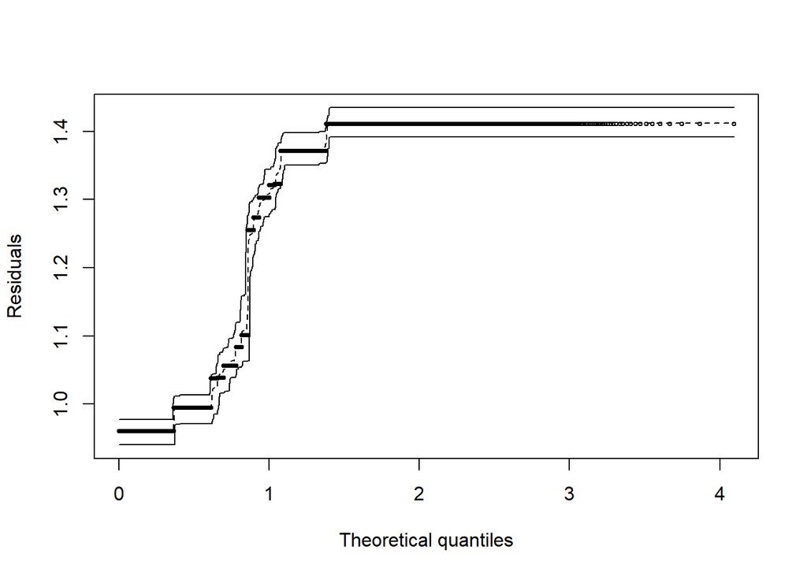

Figura 1: Gráfico de Envelope.

```r
# envelope(
#   modelo1, standardized = TRUE,
#   main = "", ylab = "quantis observados"
# )
```

#### Modelo Log-binomial

```r
modelo2 <- logbin(data = dados5, as.factor(febre) ~ vacina_cov+variante)
summary(modelo2)
```

```
##
## Call:
## logbin(formula = as.factor(febre) ~ vacina_cov + variante, data = dados5)
##
## Deviance Residuals:
##     Min       1Q   Median       3Q      Max
## -1.4109  -1.3697   0.9606   0.9966   1.2959
##
## Coefficients:
##                  Estimate Std. Error z value Pr(>|z|)
## (Intercept)     -0.461403   0.009393 -49.121  < 2e-16 ***
## vacina_covsim   -0.036761   0.025296  -1.453  0.14615
## variantegama    -0.035205   0.015167  -2.321  0.02028 *
## variantedelta   -0.083534   0.029228  -2.858  0.00426 **
## varianteomicron -0.341464   0.032071 -10.647  < 2e-16 ***
## ---
## Signif. codes:  0 '***' 0.001 '**' 0.01 '*' 0.05 '.' 0.1 ' ' 1
##
##     Null deviance: 19863  on 14689  degrees of freedom
## Residual deviance: 19629  on 14685  degrees of freedom
##   (7359 observations deleted due to missingness)
##
##   AIC: 19639
## AIC_c: 19639
##
## Number of iterations: 544 (best: 544)
```

```r
modelo3 <- glm(data = dados5, as.factor(febre) ~ vacina_cov+variante, family = binomial(link="log"))
summary(modelo3)
```

```
##
## Call:
## glm(formula = as.factor(febre) ~ vacina_cov + variante, family = binomial(link = "log"),
##     data = dados5)
##
## Deviance Residuals:
##     Min       1Q   Median       3Q      Max
## -1.4109  -1.3697   0.9606   0.9966   1.2959
##
## Coefficients:
##                  Estimate Std. Error z value Pr(>|z|)
## (Intercept)     -0.461403   0.009393 -49.121  < 2e-16 ***
## vacina_covsim   -0.036769   0.025297  -1.453  0.14609
## variantegama    -0.035206   0.015167  -2.321  0.02028 *
## variantedelta   -0.083529   0.029228  -2.858  0.00427 **
## varianteomicron -0.341455   0.032070 -10.647  < 2e-16 ***
## ---
## Signif. codes:  0 '***' 0.001 '**' 0.01 '*' 0.05 '.' 0.1 ' ' 1
##
## (Dispersion parameter for binomial family taken to be 1)
##
##     Null deviance: 19863  on 14689  degrees of freedom
## Residual deviance: 19629  on 14685  degrees of freedom
##   (7359 observations deleted due to missingness)
## AIC: 19639
##
## Number of Fisher Scoring iterations: 5
```

```r
eta <- predict(modelo3)^2
fit.modelo3 <- glm(data = dados1, as.factor(febre) ~ vacina_cov+variante+eta, family = binomial(link="log"))
anova(modelo3,fit.modelo3,test="LRT")
```

|  | Resid. Df | Resid. Dev | Df | Deviance | Pr(>Chi) |
| --- | --- | --- | --- | --- | --- |
| 1 | 14685 | 19628.54 | NA | NA | NA |
| 2 | 14684 | 19613.51 | 1 | 15.0271 | 0.0001059784 |

```r
pregibon.glm(modelo2)
```

```
##
## The Pregibon Test p-value: 0.1138. This model DOES PASS this test.
```

```
##
##  Pregibon's Link Test
##
## data:  modelo2
## T.value = -1.5816, df = 14687, p-value = 0.1138
```

```r
pregibon.glm(modelo3)
```

```
##
## The Pregibon Test p-value: 0.1137. This model DOES PASS this test.
```

```
##
##  Pregibon's Link Test
##
## data:  modelo3
## T.value = -1.5819, df = 14687, p-value = 0.1137
```

##### Análise de diagnóstico

Primeiramente, investigamos se não existe multicolinearidade nos dados, suposição muito importante em um modelo de regressão logística. Na prática, valores do teste Fator de Inflação da Variância (VIF) que excedam 10 indicam que há um problema de colinearidade. No entanto, como podemos observar em seguida, as covariáveis obtiveram valores de VIF bem abaixo de 5. Sendo assim, a condição de não-multicolinearidade está atestada.

```r
car::vif(modelo2)
```

```
##                GVIF Df GVIF^(1/(2*Df))
## vacina_cov 1.491172  1        1.221136
## variante   1.491172  3        1.068861
```

```r
hnp(modelo2)
```

```
## Binomial model
```

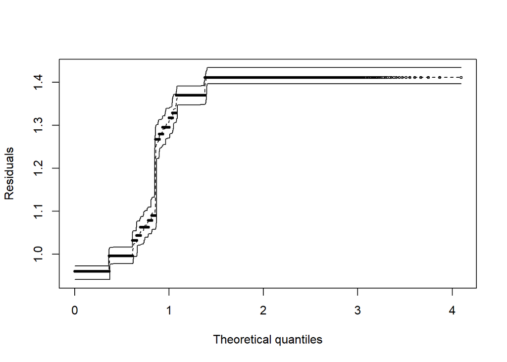

Figura 2: Gráfico de Envelope.

```r
# envelope(
#   modelo1, standardized = TRUE,
#   main = "", ylab = "quantis observados"
# )
```

```r
hnp(modelo3)
```

```
## Binomial model
```

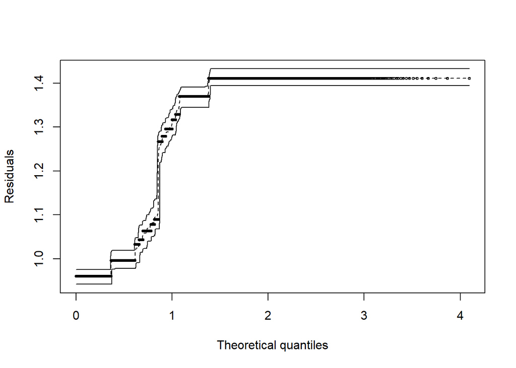

Figura 3: Gráfico de Envelope.

### Variável Tosse

#### Modelo Logistico

```r
modelo1 <- glm(data = dados5, as.factor(tosse) ~ vacina_cov+variante, family = binomial)
summary(modelo1)
```

```
##
## Call:
## glm(formula = as.factor(tosse) ~ vacina_cov + variante, family = binomial,
##     data = dados5)
##
## Deviance Residuals:
##     Min       1Q   Median       3Q      Max
## -1.7470  -1.3463   0.7002   0.8115   1.0174
##
## Coefficients:
##                 Estimate Std. Error z value Pr(>|z|)
## (Intercept)      0.94163    0.02698  34.896  < 2e-16 ***
## vacina_covsim   -0.02571    0.06047  -0.425   0.6707
## variantegama     0.33933    0.04403   7.706 1.29e-14 ***
## variantedelta    0.13977    0.07583   1.843   0.0653 .
## varianteomicron -0.52712    0.06618  -7.965 1.66e-15 ***
## ---
## Signif. codes:  0 '***' 0.001 '**' 0.01 '*' 0.05 '.' 0.1 ' ' 1
##
## (Dispersion parameter for binomial family taken to be 1)
##
##     Null deviance: 17873  on 15233  degrees of freedom
## Residual deviance: 17631  on 15229  degrees of freedom
##   (6815 observations deleted due to missingness)
## AIC: 17641
##
## Number of Fisher Scoring iterations: 4
```

```r
dados1 <- dados5[!is.na(dados5$tosse) & !is.na(dados5$vacina_cov) & !is.na(dados5$variante),]
eta <- predict(modelo1)^2
fit.modelo1 <- glm(data = dados1, as.factor(tosse) ~ vacina_cov+variante+eta, family = binomial)
anova(modelo1,fit.modelo1,test="LRT")
```

|  | Resid. Df | Resid. Dev | Df | Deviance | Pr(>Chi) |
| --- | --- | --- | --- | --- | --- |
| 1 | 15229 | 17630.97 | NA | NA | NA |
| 2 | 15228 | 17624.19 | 1 | 6.773623 | 0.009251486 |

```r
pregibon.glm(modelo1)
```

```
##
## The Pregibon Test p-value: 0.4364. This model DOES PASS this test.
```

```
##
##  Pregibon's Link Test
##
## data:  modelo1
## T.value = 0.77823, df = 15231, p-value = 0.4364
```

##### Análise de diagnóstico

Primeiramente, investigamos se não existe multicolinearidade nos dados, suposição muito importante em um modelo de regressão logística. Na prática, valores do teste Fator de Inflação da Variância (VIF) que excedam 10 indicam que há um problema de colinearidade. No entanto, como podemos observar em seguida, as covariáveis obtiveram valores de VIF bem abaixo de 5. Sendo assim, a condição de não-multicolinearidade está atestada.

```r
car::vif(modelo1)
```

```
##                GVIF Df GVIF^(1/(2*Df))
## vacina_cov 1.663649  1        1.289825
## variante   1.663649  3        1.088538
```

```r
hnp(modelo1)
```

```
## Binomial model
```

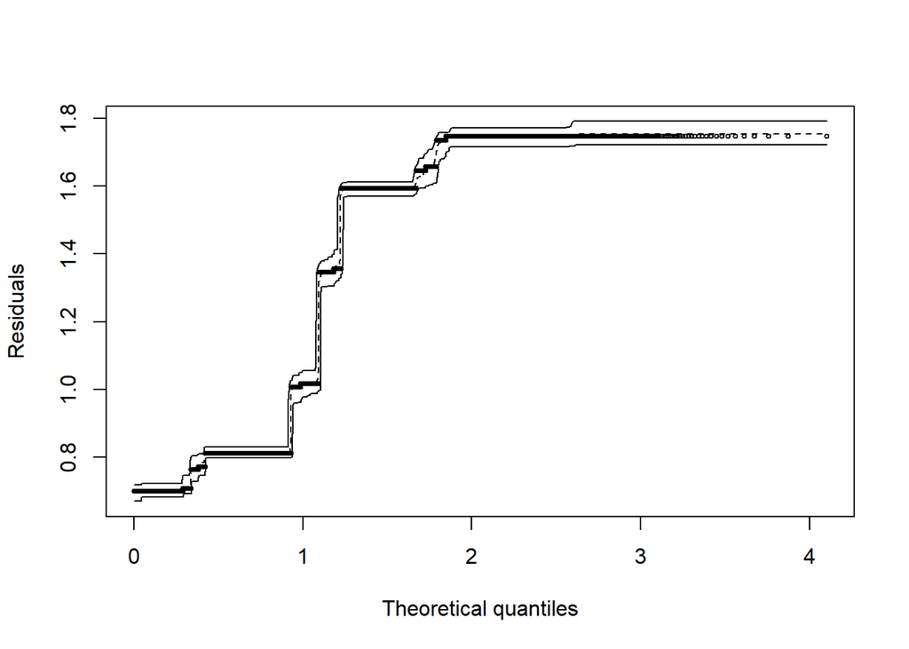

Figura 1: Gráfico de Envelope.

```r
# envelope(
#   modelo1, standardized = TRUE,
#   main = "", ylab = "quantis observados"
# )
```

#### Modelo Log-binomial

```r
modelo2 <- logbin(data = dados5, as.factor(tosse) ~ vacina_cov+variante)
summary(modelo2)
```

```
##
## Call:
## logbin(formula = as.factor(tosse) ~ vacina_cov + variante, data = dados5)
##
## Deviance Residuals:
##     Min       1Q   Median       3Q      Max
## -1.7535  -1.3518   0.7020   0.8115   1.0169
##
## Coefficients:
##                  Estimate Std. Error z value Pr(>|z|)
## (Intercept)     -0.329296   0.007571 -43.495  < 2e-16 ***
## vacina_covsim    0.004427   0.016228   0.273    0.785
## variantegama     0.082875   0.010797   7.676 1.64e-14 ***
## variantedelta    0.031791   0.019798   1.606    0.108
## varianteomicron -0.187720   0.022490  -8.347  < 2e-16 ***
## ---
## Signif. codes:  0 '***' 0.001 '**' 0.01 '*' 0.05 '.' 0.1 ' ' 1
##
##     Null deviance: 17873  on 15233  degrees of freedom
## Residual deviance: 17631  on 15229  degrees of freedom
##   (6815 observations deleted due to missingness)
##
##   AIC: 17641
## AIC_c: 17641
##
## Number of iterations: 14326 (best: 6196)
```

```r
modelo3 <- glm(data = dados5, as.factor(tosse) ~ vacina_cov+variante, family = binomial(link="log"))
summary(modelo3)
```

```
##
## Call:
## glm(formula = as.factor(tosse) ~ vacina_cov + variante, family = binomial(link = "log"),
##     data = dados5)
##
## Deviance Residuals:
##     Min       1Q   Median       3Q      Max
## -1.7535  -1.3518   0.7020   0.8115   1.0169
##
## Coefficients:
##                  Estimate Std. Error z value Pr(>|z|)
## (Intercept)     -0.329296   0.007571 -43.495  < 2e-16 ***
## vacina_covsim    0.004424   0.016228   0.273    0.785
## variantegama     0.082875   0.010797   7.676 1.64e-14 ***
## variantedelta    0.031792   0.019798   1.606    0.108
## varianteomicron -0.187718   0.022490  -8.347  < 2e-16 ***
## ---
## Signif. codes:  0 '***' 0.001 '**' 0.01 '*' 0.05 '.' 0.1 ' ' 1
##
## (Dispersion parameter for binomial family taken to be 1)
##
##     Null deviance: 17873  on 15233  degrees of freedom
## Residual deviance: 17631  on 15229  degrees of freedom
##   (6815 observations deleted due to missingness)
## AIC: 17641
##
## Number of Fisher Scoring iterations: 5
```

```r
eta <- predict(modelo3)^2
fit.modelo3 <- glm(data = dados1, as.factor(tosse) ~ vacina_cov+variante+eta, family = binomial(link="log"))
anova(modelo3,fit.modelo3,test="LRT")
```

|  | Resid. Df | Resid. Dev | Df | Deviance | Pr(>Chi) |
| --- | --- | --- | --- | --- | --- |
| 1 | 15229 | 17631.08 | NA | NA | NA |
| 2 | 15228 | 17623.96 | 1 | 7.122246 | 0.007613328 |

```r
pregibon.glm(modelo2)
```

```
##
## The Pregibon Test p-value: 0.5274. This model DOES PASS this test.
```

```
##
##  Pregibon's Link Test
##
## data:  modelo2
## T.value = -0.63197, df = 15231, p-value = 0.5274
```

```r
pregibon.glm(modelo3)
```

```
##
## The Pregibon Test p-value: 0.5274. This model DOES PASS this test.
```

```
##
##  Pregibon's Link Test
##
## data:  modelo3
## T.value = -0.63202, df = 15231, p-value = 0.5274
```

##### Análise de diagnóstico

Primeiramente, investigamos se não existe multicolinearidade nos dados, suposição muito importante em um modelo de regressão logística. Na prática, valores do teste Fator de Inflação da Variância (VIF) que excedam 10 indicam que há um problema de colinearidade. No entanto, como podemos observar em seguida, as covariáveis obtiveram valores de VIF bem abaixo de 5. Sendo assim, a condição de não-multicolinearidade está atestada.

```r
car::vif(modelo2)
```

```
##                GVIF Df GVIF^(1/(2*Df))
## vacina_cov 1.429622  1        1.195668
## variante   1.429622  3        1.061378
```

```r
hnp(modelo2)
```

```
## Binomial model
```

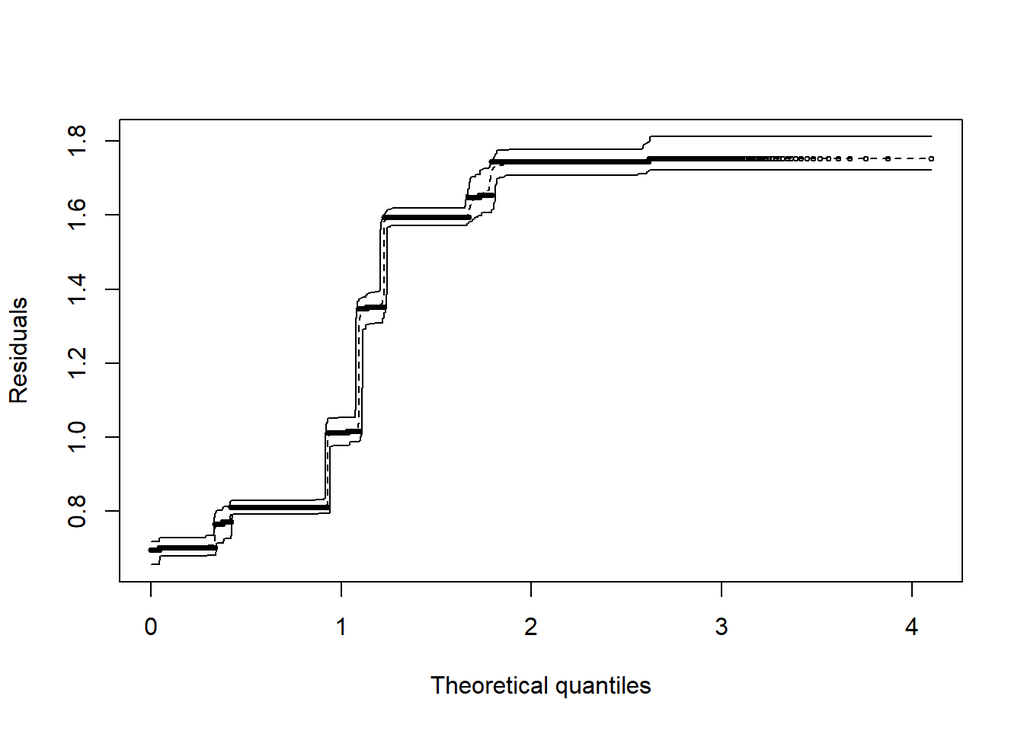

Figura 2: Gráfico de Envelope.

```r
# envelope(
#   modelo1, standardized = TRUE,
#   main = "", ylab = "quantis observados"
# )
```

```r
hnp(modelo3)
```

```
## Binomial model
```

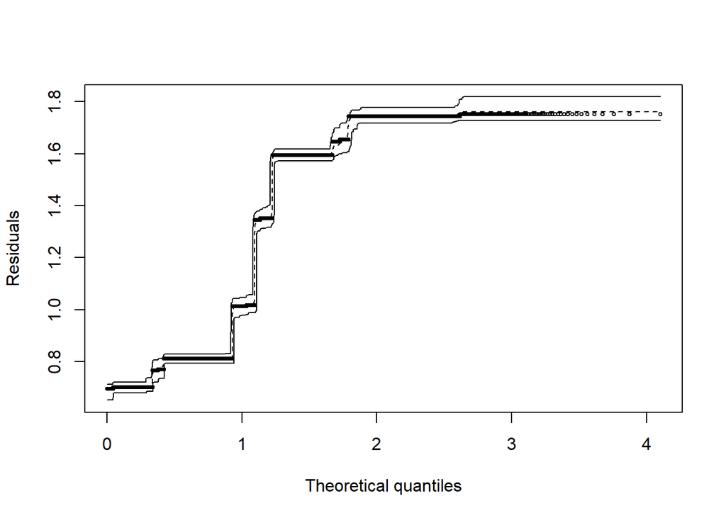

Figura 3: Gráfico de Envelope.

### Variável Garganta

#### Modelo Logistico

```r
modelo1 <- glm(data = dados5, as.factor(garganta) ~ vacina_cov+variante, family = binomial)
summary(modelo1)
```

```
##
## Call:
## glm(formula = as.factor(garganta) ~ vacina_cov + variante, family = binomial,
##     data = dados5)
##
## Deviance Residuals:
##     Min       1Q   Median       3Q      Max
## -0.8889  -0.8061  -0.8061   1.5088   1.6119
##
## Coefficients:
##                 Estimate Std. Error z value Pr(>|z|)
## (Intercept)     -0.95729    0.02906 -32.944  < 2e-16 ***
## vacina_covsim    0.02744    0.06362   0.431  0.66621
## variantegama    -0.02318    0.04521  -0.513  0.60812
## variantedelta    0.07548    0.07880   0.958  0.33813
## varianteomicron  0.20524    0.07215   2.845  0.00445 **
## ---
## Signif. codes:  0 '***' 0.001 '**' 0.01 '*' 0.05 '.' 0.1 ' ' 1
##
## (Dispersion parameter for binomial family taken to be 1)
##
##     Null deviance: 15827  on 13262  degrees of freedom
## Residual deviance: 15808  on 13258  degrees of freedom
##   (8786 observations deleted due to missingness)
## AIC: 15818
##
## Number of Fisher Scoring iterations: 4
```

```r
dados1 <- dados5[!is.na(dados5$garganta) & !is.na(dados5$vacina_cov) & !is.na(dados5$variante),]
eta <- predict(modelo1)^2
fit.modelo1 <- glm(data = dados1, as.factor(garganta) ~ vacina_cov+variante+eta, family = binomial)
anova(modelo1,fit.modelo1,test="LRT")
```

|  | Resid. Df | Resid. Dev | Df | Deviance | Pr(>Chi) |
| --- | --- | --- | --- | --- | --- |
| 1 | 13258 | 15808.02 | NA | NA | NA |
| 2 | 13257 | 15807.94 | 1 | 0.08140945 | 0.7753964 |

```r
pregibon.glm(modelo1)
```

```
##
## The Pregibon Test p-value: 0.9559. This model DOES PASS this test.
```

```
##
##  Pregibon's Link Test
##
## data:  modelo1
## T.value = 0.055263, df = 13260, p-value = 0.9559
```

##### Análise de diagnóstico

Primeiramente, investigamos se não existe multicolinearidade nos dados, suposição muito importante em um modelo de regressão logística. Na prática, valores do teste Fator de Inflação da Variância (VIF) que excedam 10 indicam que há um problema de colinearidade. No entanto, como podemos observar em seguida, as covariáveis obtiveram valores de VIF bem abaixo de 5. Sendo assim, a condição de não-multicolinearidade está atestada.

```r
car::vif(modelo1)
```

```
##                GVIF Df GVIF^(1/(2*Df))
## vacina_cov 1.636674  1        1.279326
## variante   1.636674  3        1.085576
```

```r
hnp(modelo1)
```

```
## Binomial model
```

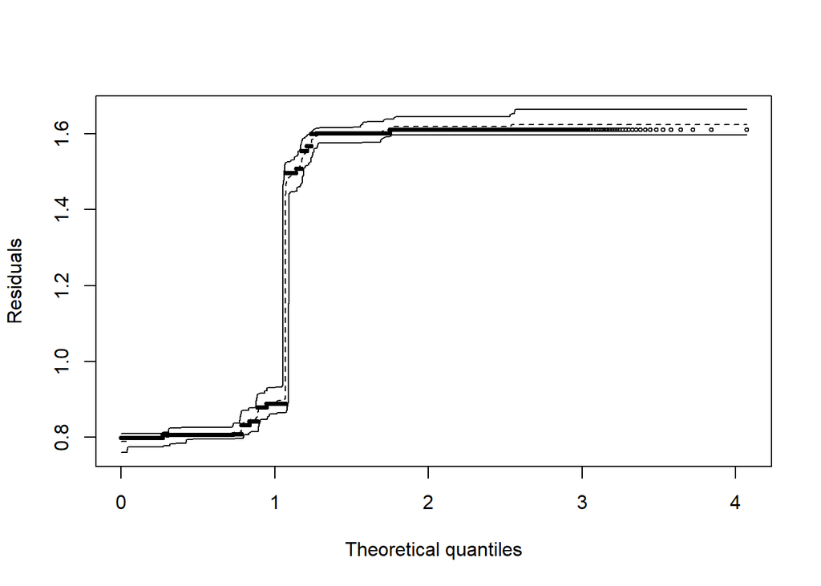

Figura 1: Gráfico de Envelope.

```r
# envelope(
#   modelo1, standardized = TRUE,
#   main = "", ylab = "quantis observados"
# )
```

#### Modelo Log-binomial

```r
modelo2 <- logbin(data = dados5, as.factor(garganta) ~ vacina_cov+variante)
summary(modelo2)
```

```
##
## Call:
## logbin(formula = as.factor(garganta) ~ vacina_cov + variante,
##     data = dados5)
##
## Deviance Residuals:
##     Min       1Q   Median       3Q      Max
## -0.8856  -0.8061  -0.7994   1.5006   1.6102
##
## Coefficients:
##                   Estimate Std. Error z value Pr(>|z|)
## (Intercept)     -1.282e+00  2.100e-02 -61.067  < 2e-16 ***
## vacina_covsim   -1.270e-06  4.474e-02   0.000  0.99998
## variantegama    -1.415e-02  3.272e-02  -0.433  0.66536
## variantedelta    6.368e-02  5.563e-02   1.145  0.25239
## varianteomicron  1.564e-01  4.994e-02   3.131  0.00174 **
## ---
## Signif. codes:  0 '***' 0.001 '**' 0.01 '*' 0.05 '.' 0.1 ' ' 1
##
##     Null deviance: 15827  on 13262  degrees of freedom
## Residual deviance: 15808  on 13258  degrees of freedom
##   (8786 observations deleted due to missingness)
##
##   AIC: 15818
## AIC_c: 15818
##
## Number of iterations: 3606 (best: 2487)
```

```r
modelo3 <- glm(data = dados5, as.factor(garganta) ~ vacina_cov+variante, family = binomial(link="log"))
summary(modelo3)
```

```
##
## Call:
## glm(formula = as.factor(garganta) ~ vacina_cov + variante, family = binomial(link = "log"),
##     data = dados5)
##
## Deviance Residuals:
##     Min       1Q   Median       3Q      Max
## -0.8891  -0.8061  -0.8061   1.5093   1.6118
##
## Coefficients:
##                 Estimate Std. Error z value Pr(>|z|)
## (Intercept)     -1.28222    0.02100 -61.067  < 2e-16 ***
## vacina_covsim    0.01959    0.04465   0.439  0.66088
## variantegama    -0.01679    0.03275  -0.513  0.60814
## variantedelta    0.05393    0.05574   0.968  0.33324
## varianteomicron  0.14327    0.05008   2.861  0.00422 **
## ---
## Signif. codes:  0 '***' 0.001 '**' 0.01 '*' 0.05 '.' 0.1 ' ' 1
##
## (Dispersion parameter for binomial family taken to be 1)
##
##     Null deviance: 15827  on 13262  degrees of freedom
## Residual deviance: 15808  on 13258  degrees of freedom
##   (8786 observations deleted due to missingness)
## AIC: 15818
##
## Number of Fisher Scoring iterations: 6
```

```r
eta <- predict(modelo3)^2
fit.modelo3 <- glm(data = dados1, as.factor(garganta) ~ vacina_cov+variante+eta, family = binomial(link="log"))
anova(modelo3,fit.modelo3,test="LRT")
```

|  | Resid. Df | Resid. Dev | Df | Deviance | Pr(>Chi) |
| --- | --- | --- | --- | --- | --- |
| 1 | 13258 | 15808.01 | NA | NA | NA |
| 2 | 13257 | 15807.94 | 1 | 0.07228175 | 0.7880431 |

```r
pregibon.glm(modelo2)
```

```
##
## The Pregibon Test p-value: 0.9413. This model DOES PASS this test.
```

```
##
##  Pregibon's Link Test
##
## data:  modelo2
## T.value = -0.07365, df = 13260, p-value = 0.9413
```

```r
pregibon.glm(modelo3)
```

```
##
## The Pregibon Test p-value: 0.9899. This model DOES PASS this test.
```

```
##
##  Pregibon's Link Test
##
## data:  modelo3
## T.value = 0.012661, df = 13260, p-value = 0.9899
```

##### Análise de diagnóstico

Primeiramente, investigamos se não existe multicolinearidade nos dados, suposição muito importante em um modelo de regressão logística. Na prática, valores do teste Fator de Inflação da Variância (VIF) que excedam 10 indicam que há um problema de colinearidade. No entanto, como podemos observar em seguida, as covariáveis obtiveram valores de VIF bem abaixo de 5. Sendo assim, a condição de não-multicolinearidade está atestada.

```r
car::vif(modelo2)
```

```
##                GVIF Df GVIF^(1/(2*Df))
## vacina_cov 1.652156  1        1.285362
## variante   1.652156  3        1.087281
```

```r
hnp(modelo2)
```

```
## Binomial model
```

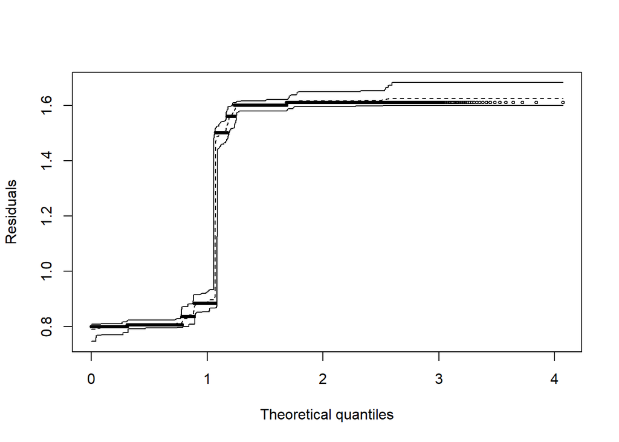

Figura 2: Gráfico de Envelope.

```r
# envelope(
#   modelo1, standardized = TRUE,
#   main = "", ylab = "quantis observados"
# )
```

```r
hnp(modelo3)
```

```
## Binomial model
```

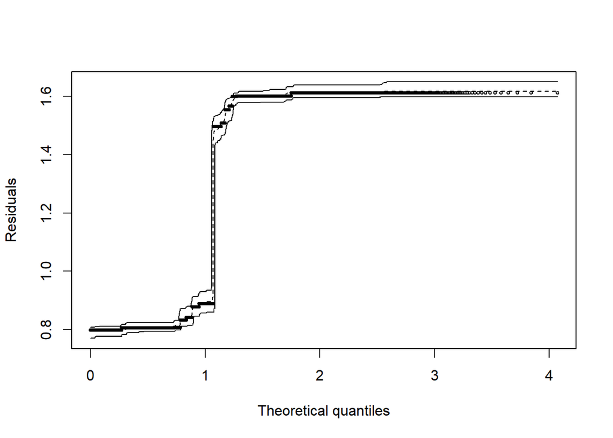

Figura 3: Gráfico de Envelope.

### Variável Saturação

#### Modelo Logistico

```r
modelo1 <- glm(data = dados5, as.factor(saturacao) ~ vacina_cov+variante, family = binomial)
summary(modelo1)
```

```
##
## Call:
## glm(formula = as.factor(saturacao) ~ vacina_cov + variante, family = binomial,
##     data = dados5)
##
## Deviance Residuals:
##     Min       1Q   Median       3Q      Max
## -1.3088  -0.8991  -0.6109   1.0515   1.9753
##
## Coefficients:
##                 Estimate Std. Error z value Pr(>|z|)
## (Intercept)     -0.69687    0.02729 -25.538  < 2e-16 ***
## vacina_covsim   -0.21356    0.06258  -3.413 0.000643 ***
## variantegama     1.00050    0.04085  24.489  < 2e-16 ***
## variantedelta    0.52029    0.07219   7.208  5.7e-13 ***
## varianteomicron -0.88717    0.08317 -10.666  < 2e-16 ***
## ---
## Signif. codes:  0 '***' 0.001 '**' 0.01 '*' 0.05 '.' 0.1 ' ' 1
##
## (Dispersion parameter for binomial family taken to be 1)
##
##     Null deviance: 18413  on 13674  degrees of freedom
## Residual deviance: 17232  on 13670  degrees of freedom
##   (8374 observations deleted due to missingness)
## AIC: 17242
##
## Number of Fisher Scoring iterations: 4
```

```r
dados1 <- dados5[!is.na(dados5$saturacao) & !is.na(dados5$vacina_cov) & !is.na(dados5$variante),]
eta <- predict(modelo1)^2
fit.modelo1 <- glm(data = dados1, as.factor(saturacao) ~ vacina_cov+variante+eta, family = binomial)
anova(modelo1,fit.modelo1,test="LRT")
```

|  | Resid. Df | Resid. Dev | Df | Deviance | Pr(>Chi) |
| --- | --- | --- | --- | --- | --- |
| 1 | 13670 | 17231.82 | NA | NA | NA |
| 2 | 13669 | 17230.82 | 1 | 1.007789 | 0.3154331 |

```r
pregibon.glm(modelo1)
```

```
##
## The Pregibon Test p-value: 3e-04. This model DOES NOT PASS this test.
```

```
##
##  Pregibon's Link Test
##
## data:  modelo1
## T.value = -3.58, df = 13672, p-value = 0.0003448
```

##### Análise de diagnóstico

Primeiramente, investigamos se não existe multicolinearidade nos dados, suposição muito importante em um modelo de regressão logística. Na prática, valores do teste Fator de Inflação da Variância (VIF) que excedam 10 indicam que há um problema de colinearidade. No entanto, como podemos observar em seguida, as covariáveis obtiveram valores de VIF bem abaixo de 5. Sendo assim, a condição de não-multicolinearidade está atestada.

```r
car::vif(modelo1)
```

```
##                GVIF Df GVIF^(1/(2*Df))
## vacina_cov 1.446962  1        1.202897
## variante   1.446962  3        1.063513
```

```r
hnp(modelo1)
```

```
## Binomial model
```

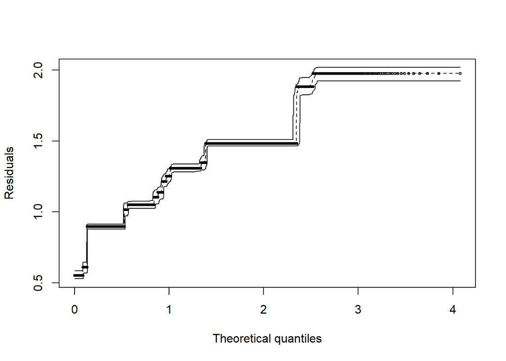

Figura 1: Gráfico de Envelope.

```r
# envelope(
#   modelo1, standardized = TRUE,
#   main = "", ylab = "quantis observados"
# )
```

#### Modelo Log-binomial

```r
modelo2 <- logbin(data = dados5, as.factor(saturacao) ~ vacina_cov+variante)
summary(modelo2)
```

```
##
## Call:
## logbin(formula = as.factor(saturacao) ~ vacina_cov + variante,
##     data = dados5)
##
## Deviance Residuals:
##     Min       1Q   Median       3Q      Max
## -1.3083  -0.8991  -0.5942   1.0519   1.9603
##
## Coefficients:
##                 Estimate Std. Error z value Pr(>|z|)
## (Intercept)     -1.10109    0.01821 -60.453  < 2e-16 ***
## vacina_covsim   -0.10025    0.03355  -2.988  0.00281 **
## variantegama     0.54785    0.02244  24.411  < 2e-16 ***
## variantedelta    0.30893    0.04118   7.502 6.27e-14 ***
## varianteomicron -0.72009    0.06399 -11.254  < 2e-16 ***
## ---
## Signif. codes:  0 '***' 0.001 '**' 0.01 '*' 0.05 '.' 0.1 ' ' 1
##
##     Null deviance: 18413  on 13674  degrees of freedom
## Residual deviance: 17234  on 13670  degrees of freedom
##   (8374 observations deleted due to missingness)
##
##   AIC: 17244
## AIC_c: 17244
##
## Number of iterations: 2073 (best: 339)
```

```r
modelo3 <- glm(data = dados5, as.factor(saturacao) ~ vacina_cov+variante, family = binomial(link="log"))
summary(modelo3)
```

```
##
## Call:
## glm(formula = as.factor(saturacao) ~ vacina_cov + variante, family = binomial(link = "log"),
##     data = dados5)
##
## Deviance Residuals:
##     Min       1Q   Median       3Q      Max
## -1.3083  -0.8991  -0.5942   1.0519   1.9603
##
## Coefficients:
##                 Estimate Std. Error z value Pr(>|z|)
## (Intercept)     -1.10109    0.01821 -60.453  < 2e-16 ***
## vacina_covsim   -0.10025    0.03355  -2.988  0.00281 **
## variantegama     0.54785    0.02244  24.411  < 2e-16 ***
## variantedelta    0.30893    0.04118   7.502 6.27e-14 ***
## varianteomicron -0.72009    0.06399 -11.254  < 2e-16 ***
## ---
## Signif. codes:  0 '***' 0.001 '**' 0.01 '*' 0.05 '.' 0.1 ' ' 1
##
## (Dispersion parameter for binomial family taken to be 1)
##
##     Null deviance: 18413  on 13674  degrees of freedom
## Residual deviance: 17234  on 13670  degrees of freedom
##   (8374 observations deleted due to missingness)
## AIC: 17244
##
## Number of Fisher Scoring iterations: 6
```

```r
eta <- predict(modelo3)^2
fit.modelo3 <- glm(data = dados1, as.factor(saturacao) ~ vacina_cov+variante+eta, family = binomial(link="log"))
anova(modelo3,fit.modelo3,test="LRT")
```

|  | Resid. Df | Resid. Dev | Df | Deviance | Pr(>Chi) |
| --- | --- | --- | --- | --- | --- |
| 1 | 13670 | 17234.38 | NA | NA | NA |
| 2 | 13669 | 17231.20 | 1 | 3.179806 | 0.07455359 |

```r
pregibon.glm(modelo2)
```

```
##
## The Pregibon Test p-value: 0. This model DOES NOT PASS this test.
```

```
##
##  Pregibon's Link Test
##
## data:  modelo2
## T.value = -6.3868, df = 13672, p-value = 1.749e-10
```

```r
pregibon.glm(modelo3)
```

```
##
## The Pregibon Test p-value: 0. This model DOES NOT PASS this test.
```

```
##
##  Pregibon's Link Test
##
## data:  modelo3
## T.value = -6.3868, df = 13672, p-value = 1.749e-10
```

##### Análise de diagnóstico

Primeiramente, investigamos se não existe multicolinearidade nos dados, suposição muito importante em um modelo de regressão logística. Na prática, valores do teste Fator de Inflação da Variância (VIF) que excedam 10 indicam que há um problema de colinearidade. No entanto, como podemos observar em seguida, as covariáveis obtiveram valores de VIF bem abaixo de 5. Sendo assim, a condição de não-multicolinearidade está atestada.

```r
car::vif(modelo2)
```

```
##                GVIF Df GVIF^(1/(2*Df))
## vacina_cov 1.252309  1        1.119066
## variante   1.252309  3        1.038210
```

```r
hnp(modelo2)
```

```
## Binomial model
```

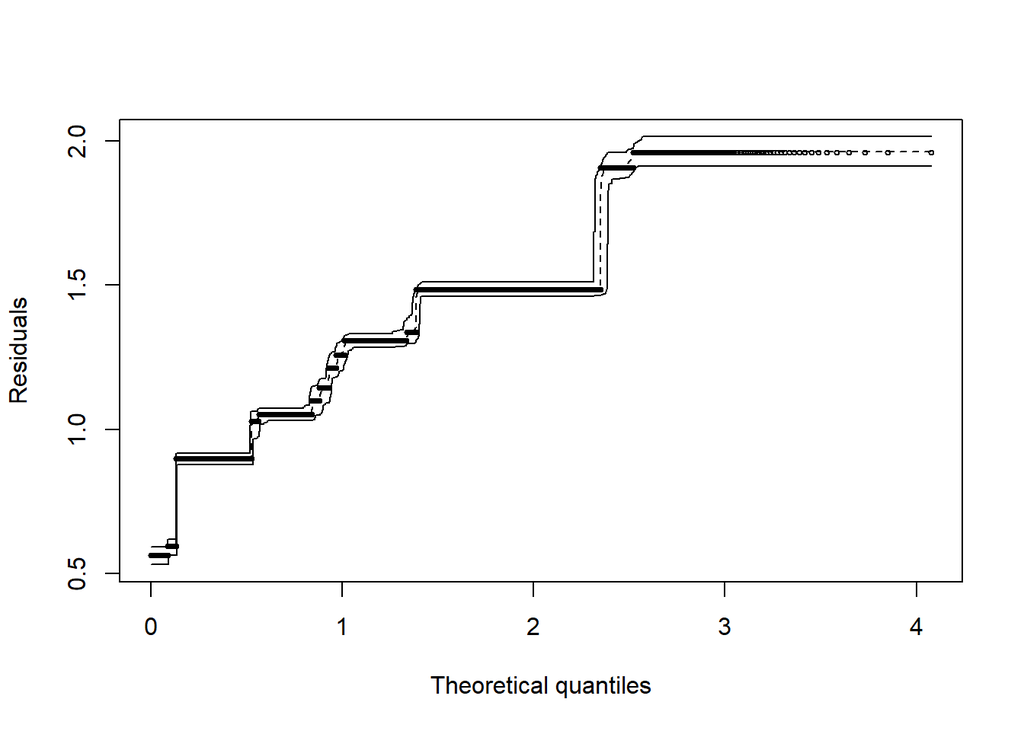

Figura 2: Gráfico de Envelope.

```r
# envelope(
#   modelo1, standardized = TRUE,
#   main = "", ylab = "quantis observados"
# )
```

```r
hnp(modelo3)
```

```
## Binomial model
```

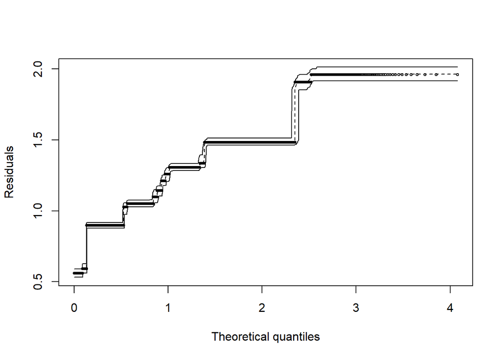

Figura 3: Gráfico de Envelope.

### Variável Dispneia

#### Modelo Logistico

```r
modelo1 <- glm(data = dados5, as.factor(dispneia) ~ vacina_cov+variante, family = binomial)
summary(modelo1)
```

```
##
## Call:
## glm(formula = as.factor(dispneia) ~ vacina_cov + variante, family = binomial,
##     data = dados5)
##
## Deviance Residuals:
##     Min       1Q   Median       3Q      Max
## -1.5813  -1.2961   0.8216   1.0632   1.6472
##
## Coefficients:
##                 Estimate Std. Error z value Pr(>|z|)
## (Intercept)      0.27472    0.02500  10.988  < 2e-16 ***
## vacina_covsim   -0.20145    0.05960  -3.380 0.000724 ***
## variantegama     0.63804    0.04073  15.666  < 2e-16 ***
## variantedelta    0.14681    0.06995   2.099 0.035832 *
## varianteomicron -1.13219    0.07047 -16.067  < 2e-16 ***
## ---
## Signif. codes:  0 '***' 0.001 '**' 0.01 '*' 0.05 '.' 0.1 ' ' 1
##
## (Dispersion parameter for binomial family taken to be 1)
##
##     Null deviance: 19770  on 14540  degrees of freedom
## Residual deviance: 18712  on 14536  degrees of freedom
##   (7508 observations deleted due to missingness)
## AIC: 18722
##
## Number of Fisher Scoring iterations: 4
```

```r
dados1 <- dados5[!is.na(dados5$dispneia) & !is.na(dados5$vacina_cov) & !is.na(dados5$variante),]
eta <- predict(modelo1)^2
fit.modelo1 <- glm(data = dados1, as.factor(dispneia) ~ vacina_cov+variante+eta, family = binomial)
anova(modelo1,fit.modelo1,test="LRT")
```

|  | Resid. Df | Resid. Dev | Df | Deviance | Pr(>Chi) |
| --- | --- | --- | --- | --- | --- |
| 1 | 14536 | 18711.96 | NA | NA | NA |
| 2 | 14535 | 18708.27 | 1 | 3.691849 | 0.05467898 |

```r
pregibon.glm(modelo1)
```

```
##
## The Pregibon Test p-value: 0.9409. This model DOES PASS this test.
```

```
##
##  Pregibon's Link Test
##
## data:  modelo1
## T.value = -0.074147, df = 14538, p-value = 0.9409
```

##### Análise de diagnóstico

Primeiramente, investigamos se não existe multicolinearidade nos dados, suposição muito importante em um modelo de regressão logística. Na prática, valores do teste Fator de Inflação da Variância (VIF) que excedam 10 indicam que há um problema de colinearidade. No entanto, como podemos observar em seguida, as covariáveis obtiveram valores de VIF bem abaixo de 5. Sendo assim, a condição de não-multicolinearidade está atestada.

```r
car::vif(modelo1)
```

```
##                GVIF Df GVIF^(1/(2*Df))
## vacina_cov 1.556455  1        1.247580
## variante   1.556455  3        1.076522
```

```r
hnp(modelo1)
```

```
## Binomial model
```

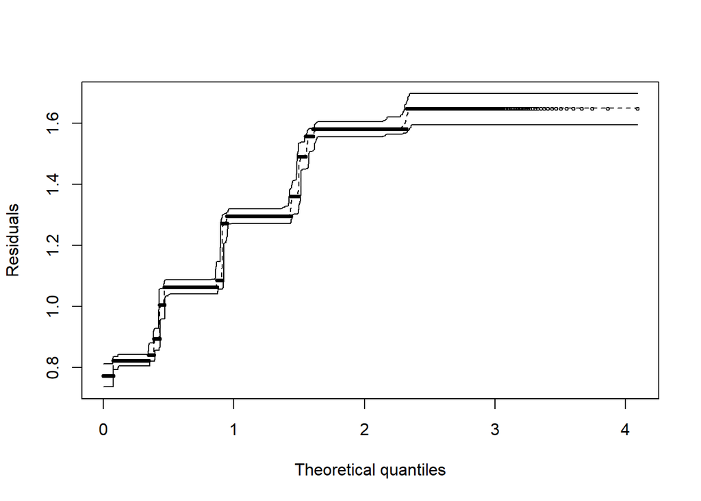

Figura 1: Gráfico de Envelope.

```r
# envelope(
#   modelo1, standardized = TRUE,
#   main = "", ylab = "quantis observados"
# )
```

#### Modelo Log-binomial

```r
modelo2 <- logbin(data = dados5, as.factor(dispneia) ~ vacina_cov+variante)
summary(modelo2)
```

```
##
## Call:
## logbin(formula = as.factor(dispneia) ~ vacina_cov + variante,
##     data = dados5)
##
## Deviance Residuals:
##    Min      1Q  Median      3Q     Max
## -1.579  -1.296   0.823   1.063   1.628
##
## Coefficients:
##                 Estimate Std. Error z value Pr(>|z|)
## (Intercept)     -0.56519    0.01079 -52.357   <2e-16 ***
## vacina_covsim   -0.05926    0.02360  -2.511   0.0120 *
## variantegama     0.22650    0.01434  15.797   <2e-16 ***
## variantedelta    0.05113    0.02869   1.782   0.0748 .
## varianteomicron -0.70033    0.04322 -16.204   <2e-16 ***
## ---
## Signif. codes:  0 '***' 0.001 '**' 0.01 '*' 0.05 '.' 0.1 ' ' 1
##
##     Null deviance: 19770  on 14540  degrees of freedom
## Residual deviance: 18717  on 14536  degrees of freedom
##   (7508 observations deleted due to missingness)
##
##   AIC: 18727
## AIC_c: 18727
##
## Number of iterations: 1684 (best: 313)
```

```r
modelo3 <- glm(data = dados5, as.factor(dispneia) ~ vacina_cov+variante, family = binomial(link="log"))
summary(modelo3)
```

```
##
## Call:
## glm(formula = as.factor(dispneia) ~ vacina_cov + variante, family = binomial(link = "log"),
##     data = dados5)
##
## Deviance Residuals:
##    Min      1Q  Median      3Q     Max
## -1.579  -1.296   0.823   1.063   1.628
##
## Coefficients:
##                 Estimate Std. Error z value Pr(>|z|)
## (Intercept)     -0.56519    0.01079 -52.357   <2e-16 ***
## vacina_covsim   -0.05928    0.02360  -2.511   0.0120 *
## variantegama     0.22650    0.01434  15.797   <2e-16 ***
## variantedelta    0.05114    0.02869   1.782   0.0747 .
## varianteomicron -0.70032    0.04321 -16.208   <2e-16 ***
## ---
## Signif. codes:  0 '***' 0.001 '**' 0.01 '*' 0.05 '.' 0.1 ' ' 1
##
## (Dispersion parameter for binomial family taken to be 1)
##
##     Null deviance: 19770  on 14540  degrees of freedom
## Residual deviance: 18717  on 14536  degrees of freedom
##   (7508 observations deleted due to missingness)
## AIC: 18727
##
## Number of Fisher Scoring iterations: 5
```

```r
eta <- predict(modelo3)^2
fit.modelo3 <- glm(data = dados1, as.factor(dispneia) ~ vacina_cov+variante+eta, family = binomial(link="log"))
anova(modelo3,fit.modelo3,test="LRT")
```

|  | Resid. Df | Resid. Dev | Df | Deviance | Pr(>Chi) |
| --- | --- | --- | --- | --- | --- |
| 1 | 14536 | 18717.07 | NA | NA | NA |
| 2 | 14535 | 18708.13 | 1 | 8.945469 | 0.002781587 |

```r
pregibon.glm(modelo2)
```

```
##
## The Pregibon Test p-value: 0. This model DOES NOT PASS this test.
```

```
##
##  Pregibon's Link Test
##
## data:  modelo2
## T.value = -5.5229, df = 14538, p-value = 3.393e-08
```

```r
pregibon.glm(modelo3)
```

```
##
## The Pregibon Test p-value: 0. This model DOES NOT PASS this test.
```

```
##
##  Pregibon's Link Test
##
## data:  modelo3
## T.value = -5.5229, df = 14538, p-value = 3.392e-08
```

##### Análise de diagnóstico

Primeiramente, investigamos se não existe multicolinearidade nos dados, suposição muito importante em um modelo de regressão logística. Na prática, valores do teste Fator de Inflação da Variância (VIF) que excedam 10 indicam que há um problema de colinearidade. No entanto, como podemos observar em seguida, as covariáveis obtiveram valores de VIF bem abaixo de 5. Sendo assim, a condição de não-multicolinearidade está atestada.

```r
car::vif(modelo2)
```

```
##                GVIF Df GVIF^(1/(2*Df))
## vacina_cov 1.275652  1        1.129448
## variante   1.275652  3        1.041411
```

```r
hnp(modelo2)
```

```
## Binomial model
```

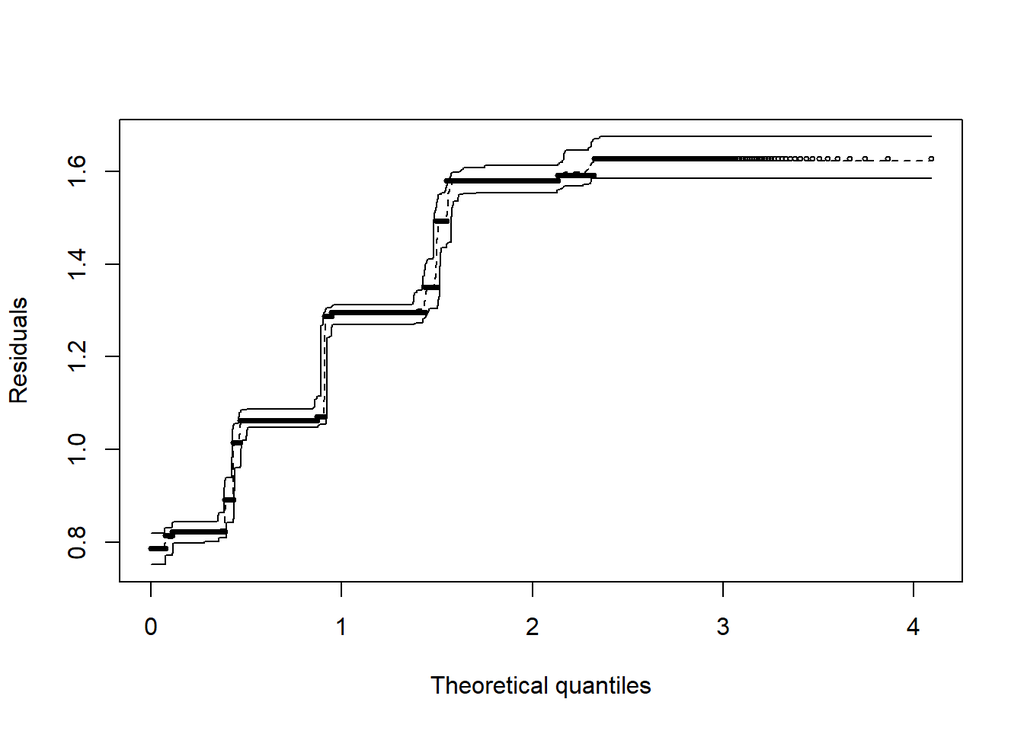

Figura 2: Gráfico de Envelope.

```r
# envelope(
#   modelo1, standardized = TRUE,
#   main = "", ylab = "quantis observados"
# )
```

```r
hnp(modelo3)
```

```
## Binomial model
```

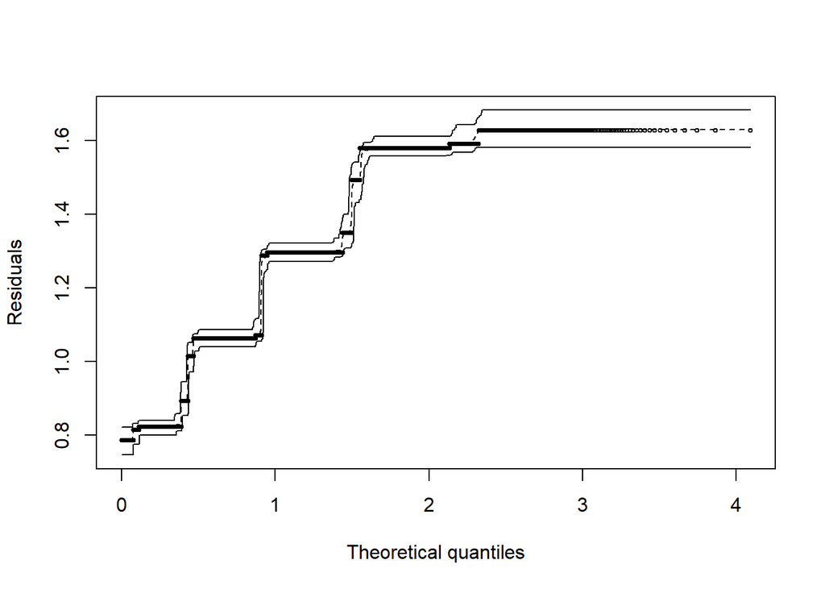

Figura 3: Gráfico de Envelope.

### Variável Fadiga

#### Modelo Logistico

```r
modelo1 <- glm(data = dados5, as.factor(fadiga) ~ vacina_cov+variante, family = binomial)
summary(modelo1)
```

```
##
## Call:
## glm(formula = as.factor(fadiga) ~ vacina_cov + variante, family = binomial,
##     data = dados5)
##
## Deviance Residuals:
##     Min       1Q   Median       3Q      Max
## -0.9317  -0.9277  -0.7120   1.4448   1.8594
##
## Coefficients:
##                 Estimate Std. Error z value Pr(>|z|)
## (Intercept)     -1.24292    0.04083 -30.443  < 2e-16 ***
## vacina_covsim   -0.01060    0.06628  -0.160  0.87292
## variantegama     0.63321    0.05217  12.137  < 2e-16 ***
## variantedelta    0.39952    0.08422   4.744  2.1e-06 ***
## varianteomicron -0.27967    0.08763  -3.192  0.00141 **
## ---
## Signif. codes:  0 '***' 0.001 '**' 0.01 '*' 0.05 '.' 0.1 ' ' 1
##
## (Dispersion parameter for binomial family taken to be 1)
##
##     Null deviance: 12649  on 10701  degrees of freedom
## Residual deviance: 12386  on 10697  degrees of freedom
##   (11347 observations deleted due to missingness)
## AIC: 12396
##
## Number of Fisher Scoring iterations: 4
```

```r
dados1 <- dados5[!is.na(dados5$fadiga) & !is.na(dados5$vacina_cov) & !is.na(dados5$variante),]
eta <- predict(modelo1)^2
fit.modelo1 <- glm(data = dados1, as.factor(fadiga) ~ vacina_cov+variante+eta, family = binomial)
anova(modelo1,fit.modelo1,test="LRT")
```

|  | Resid. Df | Resid. Dev | Df | Deviance | Pr(>Chi) |
| --- | --- | --- | --- | --- | --- |
| 1 | 10697 | 12386.02 | NA | NA | NA |
| 2 | 10696 | 12383.76 | 1 | 2.261189 | 0.1326522 |

```r
pregibon.glm(modelo1)
```

```
##
## The Pregibon Test p-value: 0.3957. This model DOES PASS this test.
```

```
##
##  Pregibon's Link Test
##
## data:  modelo1
## T.value = -0.84928, df = 10699, p-value = 0.3957
```

##### Análise de diagnóstico

Primeiramente, investigamos se não existe multicolinearidade nos dados, suposição muito importante em um modelo de regressão logística. Na prática, valores do teste Fator de Inflação da Variância (VIF) que excedam 10 indicam que há um problema de colinearidade. No entanto, como podemos observar em seguida, as covariáveis obtiveram valores de VIF bem abaixo de 5. Sendo assim, a condição de não-multicolinearidade está atestada.

```r
car::vif(modelo1)
```

```
##                GVIF Df GVIF^(1/(2*Df))
## vacina_cov 1.448756  1        1.203643
## variante   1.448756  3        1.063733
```

```r
hnp(modelo1)
```

```
## Binomial model
```

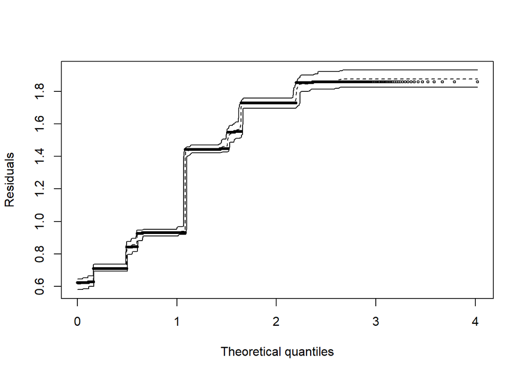

Figura 1: Gráfico de Envelope.

```r
# envelope(
#   modelo1, standardized = TRUE,
#   main = "", ylab = "quantis observados"
# )
```

#### Modelo Log-binomial

```r
modelo2 <- logbin(data = dados5, as.factor(fadiga) ~ vacina_cov+variante)
summary(modelo2)
```

```
##
## Call:
## logbin(formula = as.factor(fadiga) ~ vacina_cov + variante, data = dados5)
##
## Deviance Residuals:
##     Min       1Q   Median       3Q      Max
## -0.9313  -0.9309  -0.7120   1.4454   1.8579
##
## Coefficients:
##                   Estimate Std. Error z value Pr(>|z|)
## (Intercept)     -1.4964300  0.0316855 -47.228  < 2e-16 ***
## vacina_covsim   -0.0005645  0.0459611  -0.012 0.990200
## variantegama     0.4518377  0.0381031  11.858  < 2e-16 ***
## variantedelta    0.2918278  0.0604716   4.826 1.39e-06 ***
## varianteomicron -0.2289279  0.0684718  -3.343 0.000828 ***
## ---
## Signif. codes:  0 '***' 0.001 '**' 0.01 '*' 0.05 '.' 0.1 ' ' 1
##
##     Null deviance: 12649  on 10701  degrees of freedom
## Residual deviance: 12386  on 10697  degrees of freedom
##   (11347 observations deleted due to missingness)
##
##   AIC: 12396
## AIC_c: 12396
##
## Number of iterations: 30719 (best: 10000)
```

```r
modelo3 <- glm(data = dados5, as.factor(fadiga) ~ vacina_cov+variante, family = binomial(link="log"))
summary(modelo3)
```

```
##
## Call:
## glm(formula = as.factor(fadiga) ~ vacina_cov + variante, family = binomial(link = "log"),
##     data = dados5)
##
## Deviance Residuals:
##     Min       1Q   Median       3Q      Max
## -0.9312  -0.9311  -0.7120   1.4454   1.8578
##
## Coefficients:
##                   Estimate Std. Error z value Pr(>|z|)
## (Intercept)     -1.4964300  0.0316855 -47.228  < 2e-16 ***
## vacina_covsim   -0.0001485  0.0459555  -0.003 0.997421
## variantegama     0.4517858  0.0381035  11.857  < 2e-16 ***
## variantedelta    0.2916159  0.0604732   4.822 1.42e-06 ***
## varianteomicron -0.2292083  0.0684724  -3.347 0.000816 ***
## ---
## Signif. codes:  0 '***' 0.001 '**' 0.01 '*' 0.05 '.' 0.1 ' ' 1
##
## (Dispersion parameter for binomial family taken to be 1)
##
##     Null deviance: 12649  on 10701  degrees of freedom
## Residual deviance: 12386  on 10697  degrees of freedom
##   (11347 observations deleted due to missingness)
## AIC: 12396
##
## Number of Fisher Scoring iterations: 6
```

```r
eta <- predict(modelo3)^2
fit.modelo3 <- glm(data = dados1, as.factor(fadiga) ~ vacina_cov+variante+eta, family = binomial(link="log"))
anova(modelo3,fit.modelo3,test="LRT")
```

|  | Resid. Df | Resid. Dev | Df | Deviance | Pr(>Chi) |
| --- | --- | --- | --- | --- | --- |
| 1 | 10697 | 12386.05 | NA | NA | NA |
| 2 | 10696 | 12383.60 | 1 | 2.448382 | 0.1176461 |

```r
pregibon.glm(modelo2)
```

```
##
## The Pregibon Test p-value: 0.2446. This model DOES PASS this test.
```

```
##
##  Pregibon's Link Test
##
## data:  modelo2
## T.value = -1.1637, df = 10699, p-value = 0.2446
```

```r
pregibon.glm(modelo3)
```

```
##
## The Pregibon Test p-value: 0.2461. This model DOES PASS this test.
```

```
##
##  Pregibon's Link Test
##
## data:  modelo3
## T.value = -1.1598, df = 10699, p-value = 0.2461
```

##### Análise de diagnóstico

Primeiramente, investigamos se não existe multicolinearidade nos dados, suposição muito importante em um modelo de regressão logística. Na prática, valores do teste Fator de Inflação da Variância (VIF) que excedam 10 indicam que há um problema de colinearidade. No entanto, como podemos observar em seguida, as covariáveis obtiveram valores de VIF bem abaixo de 5. Sendo assim, a condição de não-multicolinearidade está atestada.

```r
car::vif(modelo2)
```

```
##                GVIF Df GVIF^(1/(2*Df))
## vacina_cov 1.360509  1        1.166408
## variante   1.360509  3        1.052649
```

```r
hnp(modelo2)
```

```
## Binomial model
```

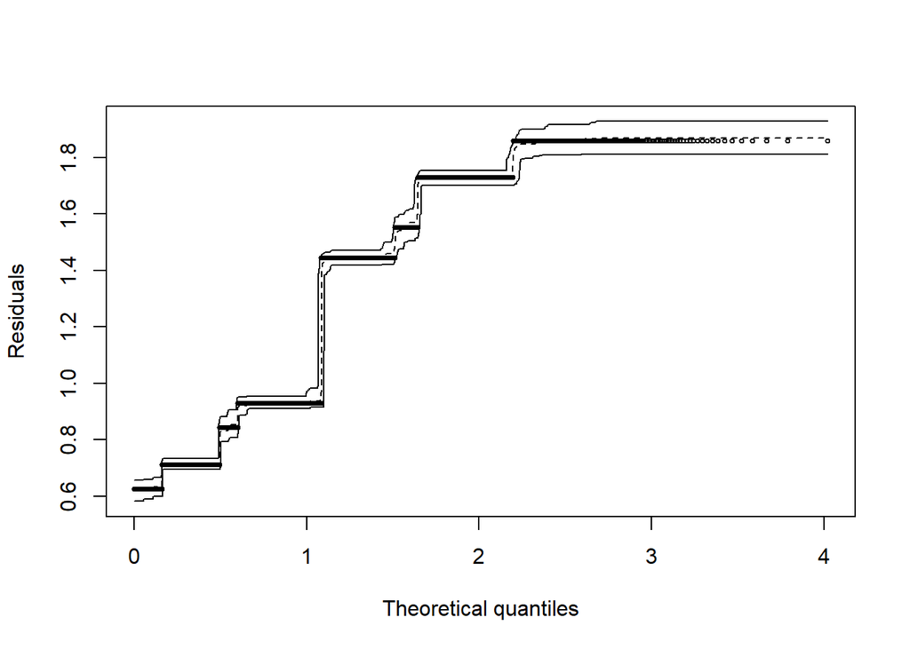

Figura 2: Gráfico de Envelope.

```r
# envelope(
#   modelo1, standardized = TRUE,
#   main = "", ylab = "quantis observados"
# )
```

```r
hnp(modelo3)
```

```
## Binomial model
```

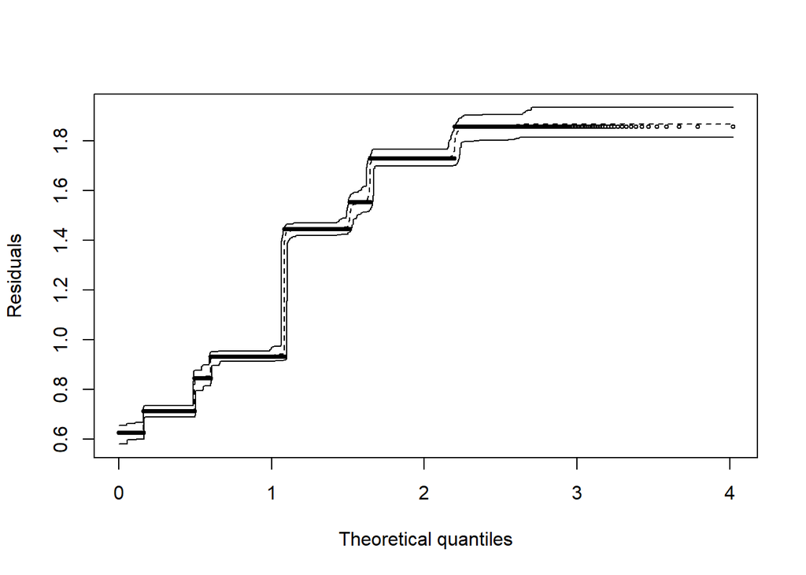

Figura 3: Gráfico de Envelope.